# Ensemble Technique: Bagging and Boosting Project 4 - Travel Package Purhase

#### Variable 'Number of Trips' Analysis

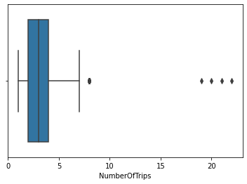

```python
#Check Distribution of data
sns.boxplot(data = data, x='NumberOfTrips')
```

```python
#View rows will Number of trips  is null
NOT_Null = data[data['NumberOfTrips'].isna()]
NOT_Null.shape
```

```
(140, 20)
```

```python
NOT_Null
```

|  | CustomerID | ProdTaken | Age | TypeofContact | CityTier | DurationOfPitch | Occupation | Gender | NumberOfPersonVisiting | NumberOfFollowups | ProductPitched | PreferredPropertyStar | MaritalStatus | NumberOfTrips | Passport | PitchSatisfactionScore | OwnCar | NumberOfChildrenVisiting | Designation | MonthlyIncome |
| --- | --- | --- | --- | --- | --- | --- | --- | --- | --- | --- | --- | --- | --- | --- | --- | --- | --- | --- | --- | --- |
| 2469 | 202469 | 0 | 54.0 | Self Enquiry | 1 | 12.0 | Salaried | Female | 3 | 4.0 | King | 3.0 | Married | NaN | 0 | 5 | 0 | 2.0 | VP | 37772.0 |
| 2473 | 202473 | 0 | 47.0 | Self Enquiry | 3 | 9.0 | Small Business | Female | 3 | 4.0 | King | 5.0 | Unmarried | NaN | 0 | 2 | 0 | 2.0 | VP | 37625.0 |
| 2506 | 202506 | 0 | 51.0 | Self Enquiry | 1 | 14.0 | Small Business | Female | 3 | 5.0 | King | 3.0 | Married | NaN | 1 | 4 | 1 | 2.0 | VP | 37418.0 |
| 2549 | 202549 | 0 | 60.0 | Company Invited | 2 | 9.0 | Salaried | Female | 3 | 5.0 | King | 3.0 | Unmarried | NaN | 0 | 2 | 1 | 2.0 | VP | 37522.0 |
| 2550 | 202550 | 0 | 51.0 | Company Invited | 1 | 7.0 | Salaried | Female | 4 | 4.0 | King | 4.0 | Unmarried | NaN | 1 | 2 | 0 | 3.0 | VP | 36850.0 |
| ... | ... | ... | ... | ... | ... | ... | ... | ... | ... | ... | ... | ... | ... | ... | ... | ... | ... | ... | ... | ... |
| 4836 | 204836 | 1 | 45.0 | Self Enquiry | 3 | 16.0 | Salaried | Male | 4 | 5.0 | Basic | 5.0 | Married | NaN | 0 | 1 | 1 | 3.0 | Executive | 37868.0 |
| 4850 | 204850 | 1 | 46.0 | Self Enquiry | 3 | 8.0 | Salaried | Male | 4 | 5.0 | Deluxe | 5.0 | Married | NaN | 0 | 4 | 1 | 3.0 | Manager | 36739.0 |
| 4851 | 204851 | 1 | 40.0 | Self Enquiry | 1 | 9.0 | Salaried | Female | 4 | 4.0 | Basic | 5.0 | Married | NaN | 1 | 1 | 1 | 1.0 | Executive | 35801.0 |
| 4868 | 204868 | 1 | 43.0 | Company Invited | 2 | 15.0 | Salaried | Female | 4 | 5.0 | Basic | 3.0 | Married | NaN | 0 | 5 | 1 | 2.0 | Executive | 36539.0 |
| 4869 | 204869 | 1 | 56.0 | Self Enquiry | 3 | 16.0 | Small Business | Female | 3 | 6.0 | Basic | 4.0 | Unmarried | NaN | 0 | 1 | 1 | 2.0 | Executive | 37865.0 |

140 rows × 20 columns

```python
#Determine Number of Trips median grouped by Product Pitched
data.groupby(['ProductPitched'])['NumberOfTrips'].median()
```

```
ProductPitched
Basic           3.0
Deluxe          3.0
King            3.0
Standard        3.0
Super Deluxe    3.0
Name: NumberOfTrips, dtype: float64
```

```python
data['NumberOfTrips'].describe()
#Median and Mean are similar; data appears to be somewhat normally distributed
```

```
count    4748.000000
mean        3.236521
std         1.849019
min         1.000000
25%         2.000000
50%         3.000000
75%         4.000000
max        22.000000
Name: NumberOfTrips, dtype: float64
```

```python
# Impute null values with Product pitched group median
data['NumberOfTrips'] = data.groupby(['ProductPitched'], sort=False)['NumberOfTrips'].apply(lambda x: x.fillna(x.median()))

data['NumberOfTrips'].isnull().sum()
```

```
0
```

```python
data['NumberOfTrips'].describe()
```

```
count    4888.000000
mean        3.229746
std         1.822769
min         1.000000
25%         2.000000
50%         3.000000
75%         4.000000
max        22.000000
Name: NumberOfTrips, dtype: float64
```

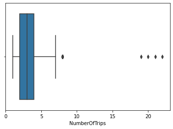

```python
#Check Distribution of data
sns.boxplot(data = data, x='NumberOfTrips')
```

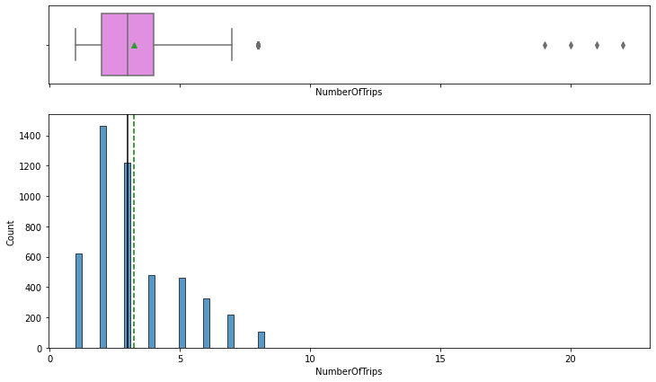

```python
histogram_boxplot(data, "NumberOfTrips")
```

```python
# Four outliers in data: 19, 20, 21, 22
```

```python
data.groupby(['ProductPitched'])['NumberOfTrips'].median()
```

```
ProductPitched
Basic           3.0
Deluxe          3.0
King            3.0
Standard        3.0
Super Deluxe    3.0
Name: NumberOfTrips, dtype: float64
```

```python
data.groupby(['ProductPitched','ProdTaken'])['NumberOfTrips'].median()
```

```
ProductPitched  ProdTaken
Basic           0            3.0
                1            3.0
Deluxe          0            3.0
                1            3.0
King            0            3.0
                1            3.0
Standard        0            3.0
                1            2.5
Super Deluxe    0            3.0
                1            2.0
Name: NumberOfTrips, dtype: float64
```

```python
data['NumberOfTrips'].value_counts(normalize=True)*100
```

```
2.0     29.950900
3.0     24.938625
1.0     12.684124
4.0      9.779051
5.0      9.369885
6.0      6.587561
7.0      4.459902
8.0      2.148118
21.0     0.020458
19.0     0.020458
22.0     0.020458
20.0     0.020458
Name: NumberOfTrips, dtype: float64
```

```python
data.groupby(['NumberOfTrips'])['ProdTaken'].value_counts(normalize=True)*100
```

```
NumberOfTrips  ProdTaken
1.0            0             81.935484
               1             18.064516
2.0            0             79.576503
               1             20.423497
3.0            0             81.214110
               1             18.785890
4.0            0             87.238494
               1             12.761506
5.0            0             86.462882
               1             13.537118
6.0            0             80.124224
               1             19.875776
7.0            0             71.559633
               1             28.440367
8.0            0             72.380952
               1             27.619048
19.0           1            100.000000
20.0           1            100.000000
21.0           0            100.000000
22.0           0            100.000000
Name: ProdTaken, dtype: float64
```

#### Insights - Number of Trips

[output not shown]

#### Variable 'Passport' Analysis

```python
data['Passport'].value_counts(normalize=True)*100
```

```
0    70.908347
1    29.091653
Name: Passport, dtype: float64
```

```python
#Understand how many Passport holders buy the product
data.groupby(['ProdTaken'])['Passport'].value_counts(normalize=True)*100
```

```
ProdTaken  Passport
0          0           76.612903
           1           23.387097
1          1           53.695652
           0           46.304348
Name: Passport, dtype: float64
```

```python
data.groupby(['ProductPitched'])['Passport'].value_counts(normalize=True)*100
```

```
ProductPitched  Passport
Basic           0           69.163952
                1           30.836048
Deluxe          0           72.286374
                1           27.713626
King            0           73.913043
                1           26.086957
Standard        0           71.698113
                1           28.301887
Super Deluxe    0           69.590643
                1           30.409357
Name: Passport, dtype: float64
```

```python
# Compute the number of products taken purchased by product pitched
data.groupby(['ProductPitched','Passport'])['ProdTaken'].value_counts(normalize=True)*100
```

```
ProductPitched  Passport  ProdTaken
Basic           0         0            81.946625
                          1            18.053375
                1         1            56.690141
                          0            43.309859
Deluxe          0         0            91.693291
                          1             8.306709
                1         0            79.166667
                          1            20.833333
King            0         0            95.294118
                          1             4.705882
                1         0            80.000000
                          1            20.000000
Standard        0         0            85.714286
                          1            14.285714
                1         0            77.142857
                          1            22.857143
Super Deluxe    0         0            96.638655
                          1             3.361345
                1         0            88.461538
                          1            11.538462
Name: ProdTaken, dtype: float64
```

```python
# Compute the number of products taken purchased by passport
data.groupby(['Passport'])['ProdTaken'].value_counts(normalize=True)*100
```

```
Passport  ProdTaken
0         0            87.709175
          1            12.290825
1         0            65.260197
          1            34.739803
Name: ProdTaken, dtype: float64
```

```python
# Compute the number of products taken purchased by passport
data.groupby(['Passport','ProductPitched'])['ProdTaken'].value_counts(normalize=True)*100
```

```
Passport  ProductPitched  ProdTaken
0         Basic           0            81.946625
                          1            18.053375
          Deluxe          0            91.693291
                          1             8.306709
          King            0            95.294118
                          1             4.705882
          Standard        0            85.714286
                          1            14.285714
          Super Deluxe    0            96.638655
                          1             3.361345
1         Basic           1            56.690141
                          0            43.309859
          Deluxe          0            79.166667
                          1            20.833333
          King            0            80.000000
                          1            20.000000
          Standard        0            77.142857
                          1            22.857143
          Super Deluxe    0            88.461538
                          1            11.538462
Name: ProdTaken, dtype: float64
```

#### Insights - Passport

- 29% of customers hold passports
- Passportholding does not appeat to greatly impact the product pitched but does appear to affect ProdTaken sepcifically those cusotmers who take the Basic Product
- Of those customers who purchased a product 54% had a passport

#### Variable 'Owns Car' Analysis

```python
data['OwnCar'].value_counts(normalize=True)*100
```

```
1    62.02946
0    37.97054
Name: OwnCar, dtype: float64
```

```python
data.groupby(['ProdTaken'])['OwnCar'].value_counts(normalize=True)*100
```

```
ProdTaken  OwnCar
0          1         62.298387
           0         37.701613
1          1         60.869565
           0         39.130435
Name: OwnCar, dtype: float64
```

```python
data.groupby(['ProductPitched'])['OwnCar'].value_counts()
```

```
ProductPitched  OwnCar
Basic           1         1084
                0          758
Deluxe          1         1058
                0          674
King            1          166
                0           64
Standard        1          484
                0          258
Super Deluxe    1          240
                0          102
Name: OwnCar, dtype: int64
```

```python
data.groupby(['ProductPitched'])['OwnCar'].value_counts(normalize=True)*100
```

```
ProductPitched  OwnCar
Basic           1         58.849077
                0         41.150923
Deluxe          1         61.085450
                0         38.914550
King            1         72.173913
                0         27.826087
Standard        1         65.229111
                0         34.770889
Super Deluxe    1         70.175439
                0         29.824561
Name: OwnCar, dtype: float64
```

```python
data.groupby(['ProductPitched','ProdTaken'])['OwnCar'].value_counts()
```

```
ProductPitched  ProdTaken  OwnCar
Basic           0          1         768
                           0         522
                1          1         316
                           0         236
Deluxe          0          1         934
                           0         594
                1          1         124
                           0          80
King            0          1         148
                           0          62
                1          1          18
                           0           2
Standard        0          1         402
                           0         216
                1          1          82
                           0          42
Super Deluxe    0          1         220
                           0         102
                1          1          20
Name: OwnCar, dtype: int64
```

```python
data.groupby(['ProductPitched','ProdTaken'])['OwnCar'].value_counts(normalize=True)*100
```

```
ProductPitched  ProdTaken  OwnCar
Basic           0          1          59.534884
                           0          40.465116
                1          1          57.246377
                           0          42.753623
Deluxe          0          1          61.125654
                           0          38.874346
                1          1          60.784314
                           0          39.215686
King            0          1          70.476190
                           0          29.523810
                1          1          90.000000
                           0          10.000000
Standard        0          1          65.048544
                           0          34.951456
                1          1          66.129032
                           0          33.870968
Super Deluxe    0          1          68.322981
                           0          31.677019
                1          1         100.000000
Name: OwnCar, dtype: float64
```

#### Insights - Own Car

- 62% of customers own a car
- ProdTaken does not appear greatly impacted by car ownership, although product pitch does with King, Standard and Super Deluxe products pitched to car owners at a higher rate than Basic and Deluxe
- Customers who buy the King and Super Deluxe Products have a higher rate of car ownership (90% and 100%) than those who take the other products (however these groups have a small number of customer each so consider size in evaluation)
- For Basic and Deluxe,the rate of car owners is approximately the rate of purchase

#### Variable 'NumberOfChildrenVisiting' Analysis

```python
data['NumberOfChildrenVisiting'].value_counts(normalize=True)*100
```

```
1.0    43.135628
2.0    27.685608
0.0    22.438822
3.0     6.739942
Name: NumberOfChildrenVisiting, dtype: float64
```

```python
data.groupby(['ProdTaken'])['NumberOfChildrenVisiting'].value_counts()
```

```
ProdTaken  NumberOfChildrenVisiting
0          1.0                         1688
           2.0                         1082
           0.0                          880
           3.0                          259
1          1.0                          392
           2.0                          253
           0.0                          202
           3.0                           66
Name: NumberOfChildrenVisiting, dtype: int64
```

```python
data.groupby(['ProdTaken'])['NumberOfChildrenVisiting'].value_counts(normalize=True)*100
```

```
ProdTaken  NumberOfChildrenVisiting
0          1.0                         43.182400
           2.0                         27.679713
           0.0                         22.512151
           3.0                          6.625735
1          1.0                         42.935378
           2.0                         27.710843
           0.0                         22.124863
           3.0                          7.228916
Name: NumberOfChildrenVisiting, dtype: float64
```

```python
data.groupby(['NumberOfChildrenVisiting'])['ProdTaken'].value_counts()
```

```
NumberOfChildrenVisiting  ProdTaken
0.0                       0             880
                          1             202
1.0                       0            1688
                          1             392
2.0                       0            1082
                          1             253
3.0                       0             259
                          1              66
Name: ProdTaken, dtype: int64
```

```python
data.groupby(['NumberOfChildrenVisiting'])['ProdTaken'].value_counts(normalize=True)*100
```

```
NumberOfChildrenVisiting  ProdTaken
0.0                       0            81.330869
                          1            18.669131
1.0                       0            81.153846
                          1            18.846154
2.0                       0            81.048689
                          1            18.951311
3.0                       0            79.692308
                          1            20.307692
Name: ProdTaken, dtype: float64
```

```python
data.groupby(['NumberOfChildrenVisiting'])['ProductPitched'].value_counts()
```

```
NumberOfChildrenVisiting  ProductPitched
0.0                       Basic             404
                          Deluxe            391
                          Standard          172
                          Super Deluxe       84
                          King               31
1.0                       Basic             793
                          Deluxe            754
                          Standard          318
                          Super Deluxe      126
                          King               89
2.0                       Basic             517
                          Deluxe            474
                          Standard          198
                          Super Deluxe       74
                          King               72
3.0                       Basic             127
                          Deluxe            112
                          Standard           53
                          King               17
                          Super Deluxe       16
Name: ProductPitched, dtype: int64
```

```python
data.groupby(['NumberOfChildrenVisiting'])['ProductPitched'].value_counts(normalize = True)*100
```

```
NumberOfChildrenVisiting  ProductPitched
0.0                       Basic             37.338262
                          Deluxe            36.136784
                          Standard          15.896488
                          Super Deluxe       7.763401
                          King               2.865065
1.0                       Basic             38.125000
                          Deluxe            36.250000
                          Standard          15.288462
                          Super Deluxe       6.057692
                          King               4.278846
2.0                       Basic             38.726592
                          Deluxe            35.505618
                          Standard          14.831461
                          Super Deluxe       5.543071
                          King               5.393258
3.0                       Basic             39.076923
                          Deluxe            34.461538
                          Standard          16.307692
                          King               5.230769
                          Super Deluxe       4.923077
Name: ProductPitched, dtype: float64
```

#### Insights - Number of Children Visiting

- The number of children under 5 does not appear to affect the overall 4 to 1 ratio of ProdTaken No to Yes
- The number of children under 5 does not appear to affect the type of project pitched other than a slightly higher than normal Super Deluxe pitch for those having 0.0 children visiting. The Percentages are as follows: Basic ~ 38%, Deluxe ~35%, Standard ~15%, King ~ 4% and Super Deluxe ~ 6%